# Fisseha Berhane, PhD

#### Data Scientist

443-970-2353 fisseha@jhu.edu CV Resume

### Top searches associated with each nation

In this post, we will get top searches associated with each nation. In doing so, first, we will scrape the list of world countries from [wikipedia](https://en.wikipedia.org/wiki/Member_states_of_the_United_Nations). We are including all member states of the United Nations. We will use the **gtrendsR** package to get the data from the Google Trends API.

#### Load all required packages

```r
library(rvest)
library(dplyr)
library(calibrate)
library(stringi)
library(ggplot2)
library(maps)
library(ggmap)
library(stringr)
library(gtrendsR)
library(dplyr)
```

#### Scrape UN member states from Wikipedia

```r
wiki= read_html("https://en.wikipedia.org/wiki/Member_states_of_the_United_Nations")

countries=wiki %>%
  html_nodes("table") %>%
    .[[2]]%>%
  html_table(fill=T)
```

#### Apply text extraction and regular expressions to remove unnecessary characters

```r
countries[,1]=stri_sub(countries[,1],3)
countries[,1]= gsub("\\(.*)","",countries[,1])
countries[,1]= gsub("\\[.*]","",countries[,1])
countries= countries[,1]
```

#### How many countries are members of the UN?

```r
length(countries)
```

193

So, there are 193 countries.

##### Let's see the first 10 countries

```r
countries[1:10]
```

1. "Afghanistan"

2. "Albania"

3. "Algeria"

4. "Andorra"

5. "Angola"

6. "Antigua and Barbuda"

7. "Argentina"

8. "Armenia"

9. "Australia"

10. "Austria"

### Getting Google Trends Data

We will use the **gtrendsR** package to get data from the Google Trends API. We need to give it our gmail user name and password.

```r
gconnect(username, password)
```

#### Top searches for India

Let's first visualize the top searched terms associated with a single country. Let's take India.

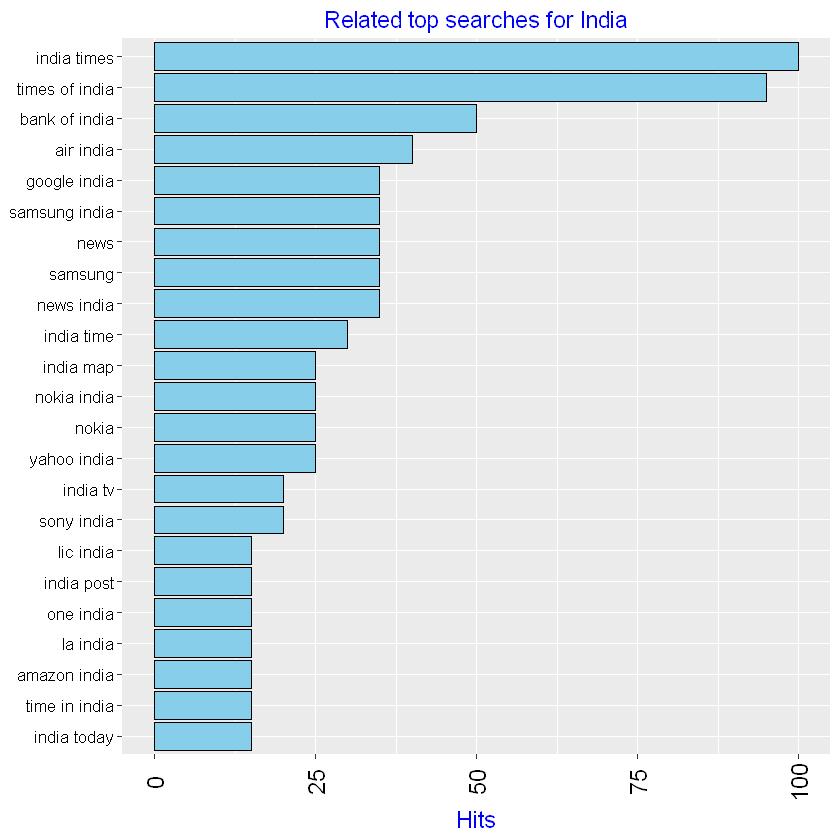

```r
data=gtrends('india')
z=as.data.frame(data$searches)
names(z)=c('searches','hits')
z=filter(z,hits>10)

 z$searches <- factor(z$searches, levels = z$searches[order(z$hits,decreasing =F)])  # re-order the terms

ggplot(z, aes(searches,hits))+
  geom_bar(stat='identity',fill="skyblue",color='black')+ylab('Hits')+
  theme(axis.title.y=element_blank(), axis.text.y = element_text(colour="black",size=10),
        axis.title.x = element_text(colour="blue",size=14),
        axis.text.x = element_text(colour="black",size=14,angle=90,hjust=.5,
                                   vjust=.5))+coord_flip()+
  ggtitle('Related top searches for India')+theme(plot.title = element_text(size = 14,colour="blue"))
```

### Spatial Distribution of the Searches

We can also see the spatial distribution of the searches. We can make animations that show how the searches vary over space and time.

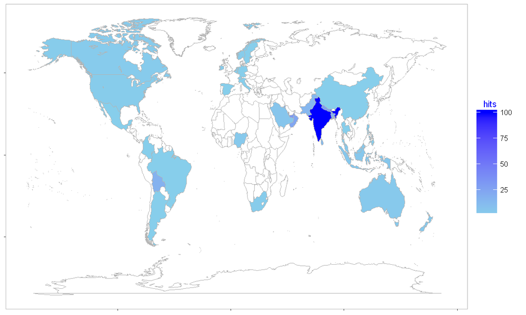

```r
regions = as.data.frame(data$regions)

names(regions)=c('region','hits')

regions$region[regions$region=="United States"] = "USA"

world_map = map_data("world")

world_map =merge(world_map, regions, by="region",all.x = TRUE)

world_map = world_map[order(world_map$group, world_map$order),]

g=ggplot(world_map, aes(x=long, y=lat, group=group))+
  geom_polygon(aes(fill=hits), color="gray70")

g+theme(axis.text.y   = element_blank(),
        axis.text.x   = element_blank(),
        axis.title.y  = element_blank(),
        axis.title.x  = element_blank(),
        panel.background = element_blank(),
        panel.grid.major = element_blank(),
        panel.grid.minor = element_blank())+
scale_fill_gradient(low = "skyblue", high = "blue", guide = "colorbar",na.value="white")+
 theme(legend.key.size = unit(1, "cm"),
         legend.title = element_text(size = 12, colour = "blue"),
         legend.title.align=0.3,legend.text = element_text(size = 10))+
         theme(panel.border = element_rect(colour = "gray70", fill=NA, size=0.5))
```

#### Top searched terms associated with each nation

```r
searches=c()

for(i in 1:dim(countries)[1]){
    data=gtrends(as.character(countries[i,1]))
    z=data$searches
    top_1=paste(as.data.frame(z)[,1][1],collapse=", ")
    searches=c(searches,top_1)

}
```

```r
Data=as.data.frame(list(Country=countries, Top_searches=searches))
```

The data frame **Data** above cotains, the top most searched term associated with each country.

### Top search terms by catagory

Now, let's group the countries based on the top most searched term.

#### Countries with top most search terms having "war" in them

```r
Data[sapply(searches, function(x) "war"%in%unlist(str_split(x,' '))),]
```

|  | Country | Top_searches |
| --- | --- | --- |
| 1 | Afghanistan | afghanistan war |
| 79 | Iraq | iraq war |
| 189 | Vietnam | vietnam war |

#### Countries with top most search terms referring to an airline

```r
Data[sapply(searches, function(x) "air"%in%unlist(str_split(x,' '))|
    "airways"%in%unlist(str_split(x,' '))),]
```

|  | Country | Top_searches |
| --- | --- | --- |
| 13 | Bahrain | bahrain air |
| 32 | Canada | air canada |
| 89 | Kuwait | kuwait airways |
| 109 | Mauritius | air mauritius |
| 122 | New Zealand | new zealand air |
| 127 | Oman | oman air |
| 137 | Qatar | qatar airways |
| 151 | Serbia | serbia air |
| 186 | Uzbekistan | uzbekistan airways |

#### Countries with top most search terms having "hotel" in them

```r
Data[sapply(searches, function(x) "hotel"%in%unlist(str_split(x,' '))),]
```

|  | Country | Top_searches |
| --- | --- | --- |
| 4 | Andorra | hotel andorra |
| 106 | Malta | hotel malta |
| 142 | Rwanda | hotel rwanda |
| 147 | San Marino | san marino hotel |
| 156 | Slovenia | hotel slovenia |

#### Countries with top most search terms referring to thier past history

```r
Data[sapply(searches, function(x) "ancient"%in%unlist(str_split(x,' '))),]
```

|  | Country | Top_searches |
| --- | --- | --- |
| 52 | Egypt | ancient egypt |
| 66 | Greece | ancient greece |

#### Countries where weather is the top search

```r
Data[sapply(searches, function(x) "weather"%in%unlist(str_split(x,' '))),]
```

|  | Country | Top_searches |
| --- | --- | --- |
| 15 | Barbados | barbados weather |
| 43 | Cyprus | weather cyprus |

#### Getting the map of the country is most important

```r
Data[sapply(searches, function(x) "map"%in%unlist(str_split(x,' '))),]
```

|  | Country | Top_searches |
| --- | --- | --- |
| 6 | Antigua and Barbuda | antigua map |
| 20 | Bhutan | bhutan map |
| 82 | Italy | italy map |
| 86 | Kazakhstan | kazakhstan map |
| 90 | Kyrgyzstan | map kyrgyzstan |
| 115 | Morocco | map morocco |
| 131 | Papua New Guinea | new guinea map |
| 161 | Spain | map spain |

#### What about Africa?

Many people consider Africa as a single country. Others, on the other hand, when they search for information related to an African country, they add the word "Africa" to the country name. Let's see countries, whose top most search term is the name of the county plus Africa.

```r
Data[sapply(searches, function(x) "africa"%in%unlist(str_split(x,' '))),]
```

|  | Country | Top_searches |
| --- | --- | --- |
| 23 | Botswana | botswana africa |
| 33 | Central African Republic | central africa republic |
| 48 | Djibouti | africa djibouti |
| 54 | Equatorial Guinea | equatorial guinea africa |
| 94 | Lesotho | lesotho africa |
| 108 | Mauritania | mauritania africa |
| 116 | Mozambique | mozambique africa |
| 118 | Namibia | namibia africa |
| 159 | South Africa | india south africa |
| 165 | Swaziland | swaziland africa |
| 183 | Tanzania | tanzania africa |
| 191 | Zambia | zambia africa |

As shown in the table above, the top search for many African countries is the country name plus Africa. Of course, central africa republic is a country and I do not know why "india south africa" is the top searched term associated with South Africa.